# R course day 2: Statistics

# 5 Association between variables

Until now we have discussed how to test if there is a statistically significant difference between two groups, multiple groups or paired samples within a group. Statistical analyses also often revolve around finding association between variables. For example, in the **iris** dataset, we could wonder whether the length of the petals is associated to the width of the petals, and whether knowledge about one of those two measurements is predictive for the other.

In this section, we will discuss *association between discrete variables*, *correlation*, and *linear models* to identify and examine the association between variables.

## 5.1 Association between discrete variables

If you want to know the relationship between two categorical variables (also known as discrete data), you can use the Chi-square test or the Fisher’s exact test. Categorical variables, as the name implies, are variables that indicate membership of a category (gender: M/F, Iris species: *virginica* / *versicolor* / *setosa*). Categorical variables are called factors in R (see yesterday’s info on data types).

Imagine that you have some data on the food preferences (vegetarian vs. non-vegetarian) and favourite sport to play (soccer vs. volleyball) of a group of 50 people. You can think of this data as a 2x2 table (also called a [contingency table](https://en.wikipedia.org/wiki/Contingency_table#Example)) with counts for each of the preferences for both variables:

```
##             food
## sport        non-veg veg
##   soccer          30   7
##   volleyball       8   5
```

You might want to figure out whether soccer players are more likely to be vegetarian, and as you can appreciate in the table, that means you compare the proportion of vegetarian soccer players to the proportion of vegetarion volleyball players.

### 5.1.1 Chi-square test

The Chi-square test allows you to test whether there is a relationship between two variables, but it does not tell you about the direction and size of the relationship.  
*Null Hypothesis*: There is no relationship between the two variables  
When you reject the null hypothesis with a Chi-Square, you are saying that there is a relationship between the two variables.

The Chi-square test is used to find if two nominal or ordinal (both categorical) variables are independent. R has a built-in dataset called **survey** with student smoking and exercise habits. Load in the dataset:

```r
library(MASS)
head(survey)
```

```
##      Sex Wr.Hnd NW.Hnd W.Hnd    Fold Pulse    Clap Exer Smoke Height
## 1 Female   18.5   18.0 Right  R on L    92    Left Some Never 173.00
## 2   Male   19.5   20.5  Left  R on L   104    Left None Regul 177.80
## 3   Male   18.0   13.3 Right  L on R    87 Neither None Occas     NA
## 4   Male   18.8   18.9 Right  R on L    NA Neither None Never 160.00
## 5   Male   20.0   20.0 Right Neither    35   Right Some Never 165.00
## 6 Female   18.0   17.7 Right  L on R    64   Right Some Never 172.72
##        M.I    Age
## 1   Metric 18.250
## 2 Imperial 17.583
## 3     <NA> 16.917
## 4   Metric 20.333
## 5   Metric 23.667
## 6 Imperial 21.000
```

**Q16**

- Construct a contingency table for smoking and exercise by filling in the **???**: `table(survey$???, survey$???)`
- Save the result as `tblSmoke`
- How many individuals are in the contingency table?
- Run a Chi-square test on this sample using `chisq.test`
- What is the null hypothesis and do you reject it?

```r
#Question 16
#Code
tblSmoke = table(survey$Smoke, survey$Exer)
sum(tblSmoke)
```

```
## [1] 236
```

```r
chisq.test(tblSmoke)
```

```
##
##  Pearson's Chi-squared test
##
## data:  tblSmoke
## X-squared = 5.4885, df = 6, p-value = 0.4828
```

```r
#Answer
#236 students
#Null hypothesis: smoking habit is independent of the exercise level of the students
#As the p-value 0.4828 is greater than the .05 significance level, we do not reject the null hypothesis
```

**Q17**

- Use `?survey` to see the description of the columns
- Run a chi-square test to test if which hand is on top after clapping and exercise levels are independent
- What is the null hypothesis and do you reject it (at 0.05 significance level)?
- Do you think this is correct?

```r
#Question 17
#Code
tblClap <- table(survey$Clap, survey$Exer)
chisq.test(tblClap)
```

```
##
##  Pearson's Chi-squared test
##
## data:  tblClap
## X-squared = 13.32, df = 4, p-value = 0.009816
```

```r
#Answer
#As the p-value 0.009816 is lower than the .05 significance level, we reject the null hypothesis that which hand is on top after clapping is independent of the exercise level of the students.
#This seems like it might be due to some spurious relation; it seems like there is no logical explanation for this dependence
```

### 5.1.2 Fisher’s exact test

When you ran the Chi-square test, you may have seen this warning:  
`Warning message: In chisq.test(tblClap) : Chi-squared approximation may be incorrect`  
The Chi-square test gives an estimation of the p-value, so the approximation could be incorrect. The Fisher’s exact test gives (as the name implies) the exact value of the p-value. There is some discussion about whether it is better to use a Chi-square or Fisher’s exact test. Traditionally, it was not possible to calculate the exact value (by hand), so the latter has only been used regularly since statistics are done on computers. When the numbers in the contingency table are small (i.e. one of the cells has a value of < 5), it is often advised to use Fisher’s exact test.

**Q18**: Redo the Chi-square exercises but instead use the Fisher Exact test. What are the differences? *Hint*: see `?fisher.test` for information how to use the function.

```r
#Question 18
#Code
fisher.test(tblSmoke)
```

```
##
##  Fisher's Exact Test for Count Data
##
## data:  tblSmoke
## p-value = 0.4138
## alternative hypothesis: two.sided
```

```r
fisher.test(tblClap)
```

```
##
##  Fisher's Exact Test for Count Data
##
## data:  tblClap
## p-value = 0.007343
## alternative hypothesis: two.sided
```

```r
#Answer
#Slight less significant p-value in chi-square test of moking behaviour, slightly more significant in test of clapping hands
#DP-values remain in the same order of magnitude
```

## 5.2 Correlation

A correlation is a statistic that indicates how two variables are related to one another. In the **iris** dataset, we hyopthesize that the wider a plants petals are, the longer they get. We would like to test whether we have evidence for this hypothesis. Often plotting the two variables will already tell you if they correlate.

### 5.2.1 Parametric: Pearson correlation

Make a scatterplot between Sepal length and Sepal width:

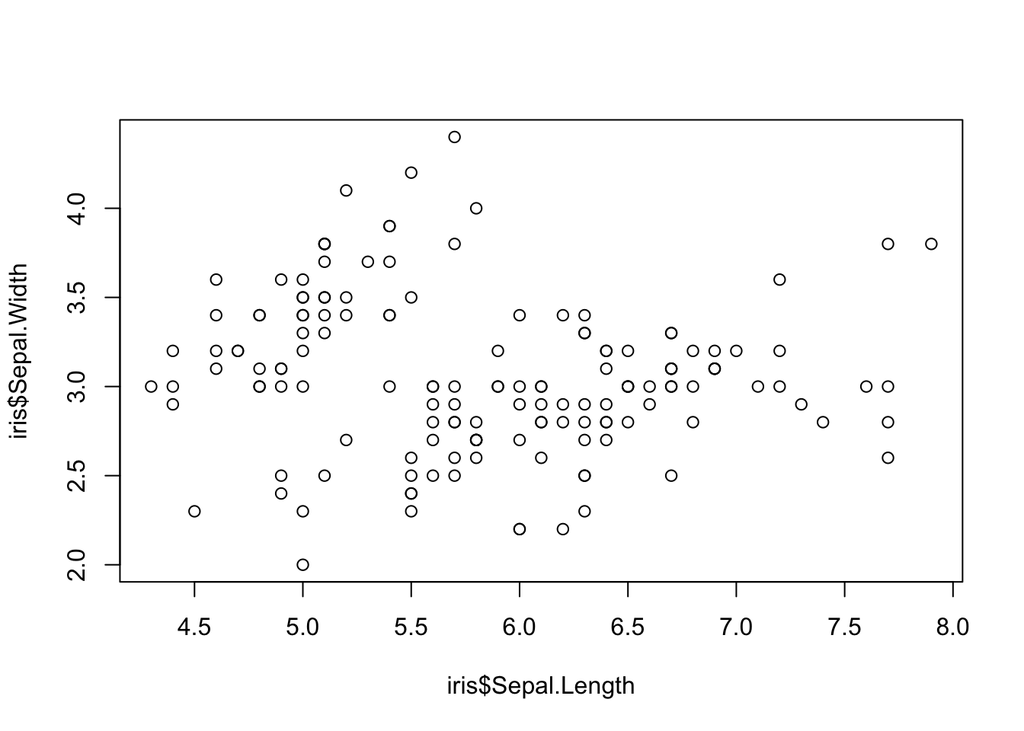

```r
plot(iris$Sepal.Length, iris$Sepal.Width)
```

This plot indicates there might be a slight negative correlation between the Sepal length and Sepal width.

**Q19**:

- What is the correlation coefficient belonging to the plot above? Use the function `cor()`
- What is the possible range of correlation coefficients (i.e. what is the maximum and minimum possible correlation between any pair of variables)?

```r
#Question 19
#Code
cor(iris$Sepal.Length, iris$Sepal.Width)
```

```
## [1] -0.1175698
```

```r
#Answer
#The correlation is -0.1176
#The correlation coefficient must always lie between -1 and 1
```

**Q20**:

- What correlation coefficient do you get if you correlate Sepal length of *versicolor* with the Sepal width of *versicolor*?
- Make a scatterplot using `plot()`
- Why is the correlation coefficient so different (size and direction)?
- Use the function `cor.test()` to test whether the correlation is significantly different from 0
- Is the correlation significant?
- What is the associated p-value?

```r
#Question 20
#Code
cor(iris[iris$Species=='versicolor',]$Sepal.Width, iris[iris$Species=='versicolor',]$Sepal.Length)
```

```
## [1] 0.5259107
```

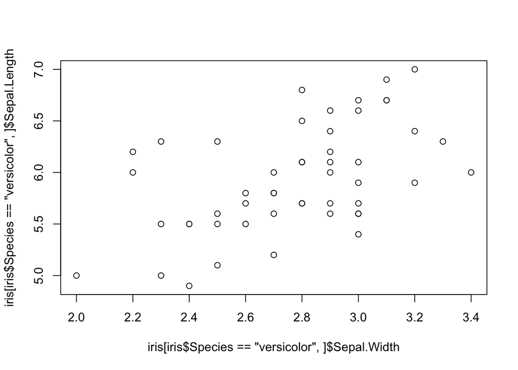

```r
plot(iris[iris$Species=='versicolor',]$Sepal.Width, iris[iris$Species=='versicolor',]$Sepal.Length)
```

```r
cor.test(iris[iris$Species=='versicolor',]$Sepal.Width, iris[iris$Species=='versicolor',]$Sepal.Length)
```

```
##
##  Pearson's product-moment correlation
##
## data:  iris[iris$Species == "versicolor", ]$Sepal.Width and iris[iris$Species == "versicolor", ]$Sepal.Length
## t = 4.2839, df = 48, p-value = 8.772e-05
## alternative hypothesis: true correlation is not equal to 0
## 95 percent confidence interval:
##  0.2900175 0.7015599
## sample estimates:
##       cor
## 0.5259107
```

```r
#Answer
#Correlation is 0.52
#Before we tried to look at the sepal width and length without taking the species into account
#When you look within the species, it becomes clear that the correlation is actually quite strong
#The correlation is significant with a p-value of 8.772e-05
```

**Q21**:

- Instead of calculating the correlation between two columns at a time, it is also possible to give a whole dataframe input for the correlation function
- Select the columns with numeric values from the **iris** dataframe by using `iris[1:4]`
- Get the correlation coefficients for all numeric columns in the iris dataframe and call it `cormat`
- The output of this command is called a ‘correlation matrix’. Why are some values in this matrix 1?

```r
#Question 21
#Code
cormat <- cor(iris[1:4])
cormat
```

```
##              Sepal.Length Sepal.Width Petal.Length Petal.Width
## Sepal.Length    1.0000000  -0.1175698    0.8717538   0.8179411
## Sepal.Width    -0.1175698   1.0000000   -0.4284401  -0.3661259
## Petal.Length    0.8717538  -0.4284401    1.0000000   0.9628654
## Petal.Width     0.8179411  -0.3661259    0.9628654   1.0000000
```

```r
#Answer
#The cells with a correlation of 1 are showing the correlation of the variable with itself, which is 1 by definition
```

**Q22**:

- Make a scatterplot for the 4 characteristics using `plot()` again (the result should look like below)
- Add colours to each of the species with with `col=iris$Species`
- Compare the correlation matrix and the plots
- Do you think the negative correlation coefficients that you see in the matrix are a good reflection of the relationships between the variables (e.g. between Petal length and Sepal width)?

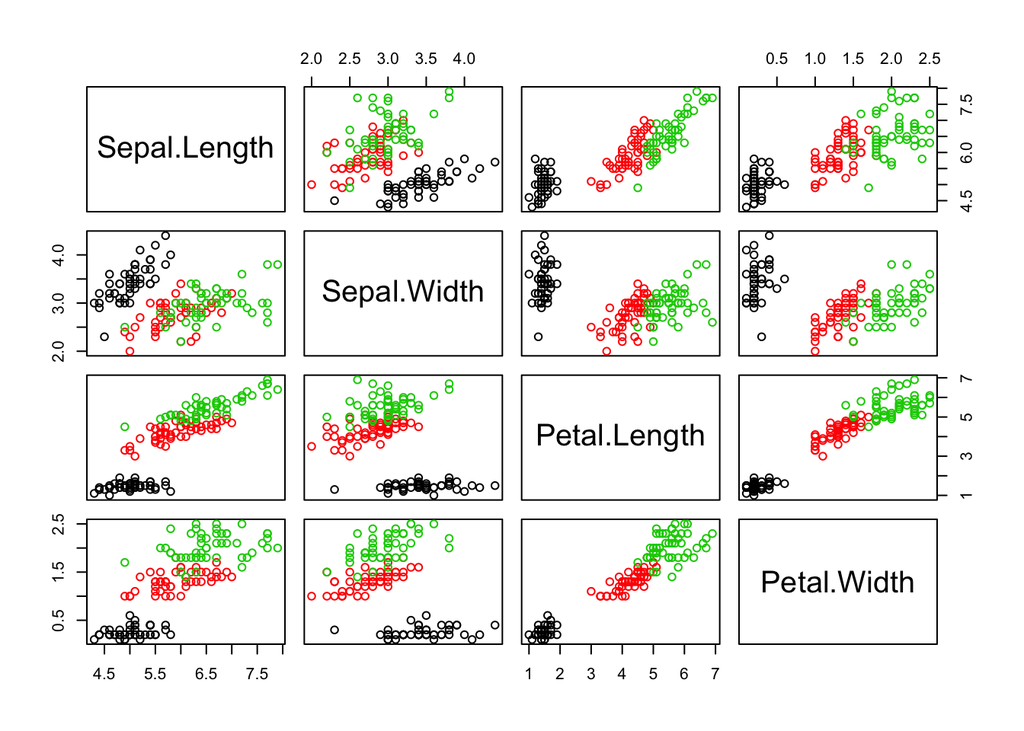

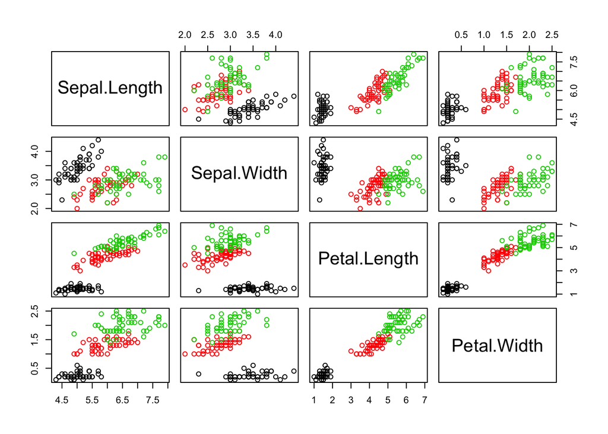

```r
#Question 22
#Code
plot(iris[1:4], col=iris$Species)
```

```r
#Answer
#The negative values show the correlation without taking species into account. It is clear that within each species of iris, there is a (slight) positive correlation. It's always good to do some plotting before you run statistical tests.
```

### 5.2.2 Non-parametric: Spearman rank correlation

The non-parametric version of the Pearson correlation is called the Spearman rank correlation. Like the Wilcoxon test, this function first ranks all observations and then calculates the correlations across the ranks, rather than across the real values.  
The default of `cor()` is to use the parametric Pearson correlation, but you can change the method of correlation by adding `method = 'spearman'` to your command.

**Q23**: Answer **Q20** again, but this time using the Spearman rank correlation

```r
#Question 23
#Code
cor(iris[iris$Species=='versicolor',]$Sepal.Width, iris[iris$Species=='versicolor',]$Sepal.Length, method = 'spearman')
```

```
## [1] 0.517606
```

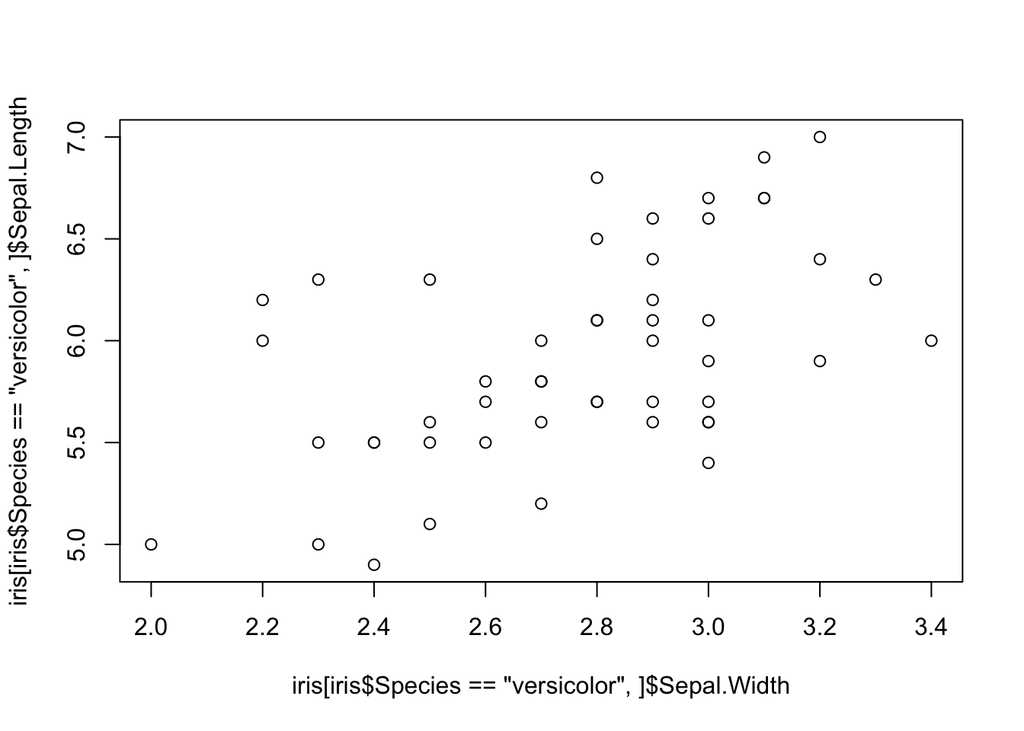

```r
plot(iris[iris$Species=='versicolor',]$Sepal.Width, iris[iris$Species=='versicolor',]$Sepal.Length)
```

```r
cor.test(iris[iris$Species=='versicolor',]$Sepal.Width, iris[iris$Species=='versicolor',]$Sepal.Length, method = 'spearman')
```

```
##
##  Spearman's rank correlation rho
##
## data:  iris[iris$Species == "versicolor", ]$Sepal.Width and iris[iris$Species == "versicolor", ]$Sepal.Length
## S = 10046, p-value = 0.0001184
## alternative hypothesis: true rho is not equal to 0
## sample estimates:
##      rho
## 0.517606
```

```r
#Answer
#Correlation is 0.517, so very similar to before
#Before we tried to look at the sepal width and length without taking the species into account
#When you look within the species, it becomes clear that the correlation is actually quite strong
#The correlation is significant with a p-value of 0.0001184
```

## 5.3 Linear models

Now that we have seen that the petal width a petal length is strongly correlated we can use regression analysis to predict values that we have no measured. Regression finds a relationship between the predictor variable (measured in experiments) and response variable (derived from predictor variable). If there is a linear relationship between these two variables they can be represented by a line. The regression formula is

`y = ax + b`

where y is the response variable, x is the predictor variable, and a and b are the coefficients. We want to predict petal length using the petal width.

A linear model is fitted using the function `lm()` as follows:

```r
modelname <- lm(formula, data=mydata)
```

In the case of the **iris** dataset, this would for example look like this (where `m1` stands for model 1):

```r
m1 <- lm(Petal.Length ~ Petal.Width, data=iris)
```

**Q24**: Using the results from `m1`, write down the mathematical equation to calculate petal length given the petal width (fill in the values of `a` and `b`)

```r
#Question 24
#Code
m1 <- lm(Petal.Length ~ Petal.Width, data=iris)

#Answer
#Petal Length = 2.230 * Petal Width + 1.084
```

**Q25**: Examine the model output by using `summary(m1)`. This command will show you the formula, the quartiles of the residual values, the coefficient estimates, standard errors and p-values, the residual standard error, the explained variance and the F-statistic. How much of the variation in petal length is explained by the variation in petal width?

```r
#Question 25
#Code
summary(m1)
```

```
##
## Call:
## lm(formula = Petal.Length ~ Petal.Width, data = iris)
##
## Residuals:
##      Min       1Q   Median       3Q      Max
## -1.33542 -0.30347 -0.02955  0.25776  1.39453
##
## Coefficients:
##             Estimate Std. Error t value Pr(>|t|)
## (Intercept)  1.08356    0.07297   14.85   <2e-16 ***
## Petal.Width  2.22994    0.05140   43.39   <2e-16 ***
## ---
## Signif. codes:  0 '***' 0.001 '**' 0.01 '*' 0.05 '.' 0.1 ' ' 1
##
## Residual standard error: 0.4782 on 148 degrees of freedom
## Multiple R-squared:  0.9271, Adjusted R-squared:  0.9266
## F-statistic:  1882 on 1 and 148 DF,  p-value: < 2.2e-16
```

```r
#Answer
#The R-squared (explained variance) is 0.9271, so ~ 92% of the variation in petal length is explained by the variation in petal width.
```

**Q26**:

- Given this strong association, you can predict the petal length from the petal width using `predict.lm()`
- Imagine you have measured another iris flower, and its petal width is 4 cm
- Make a new data frame with one measurement: `measured <- data.frame(Petal.Width=4)`
- Predict what the petal length would be for this measurement using `predict.lm(???, ???)`
- The first argument is the model name
- The second argument is the name of the data frame with the measurement
- What is the predicted petal length?
- Save the predicted length as `predicted`

```r
#Question 26
#Code
measured <- data.frame(Petal.Width=4)
predicted <- predict.lm(m1,measured)
print(predicted)
```

```
##        1
## 10.00332
```

```r
#Answer
#The petal length is predicted to be 10 centimeters
```

We want to plot the observed points and regression line to have a look at how well it fits:

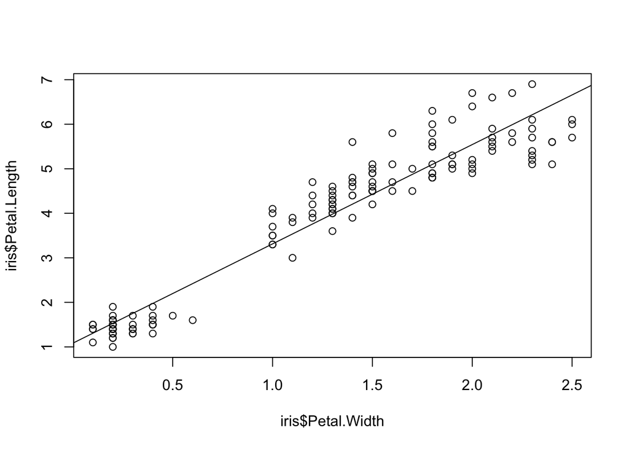

```r
# Plot the chart
m1 <- lm(Petal.Length ~ Petal.Width, data=iris)
plot(iris$Petal.Width,iris$Petal.Length, abline(m1))
```

**Q27**:

- Run the same plot again, but this time add specific ranges for the x- and y-axes by adding:
  - `xlim=c(0,4)`
  - `ylim=c(0,11)`
- Add the extra (predicted) point to the plot using `points(4,predicted, col="red")`
- *Hint*: this last line has to be outside of the brackets of `plot`

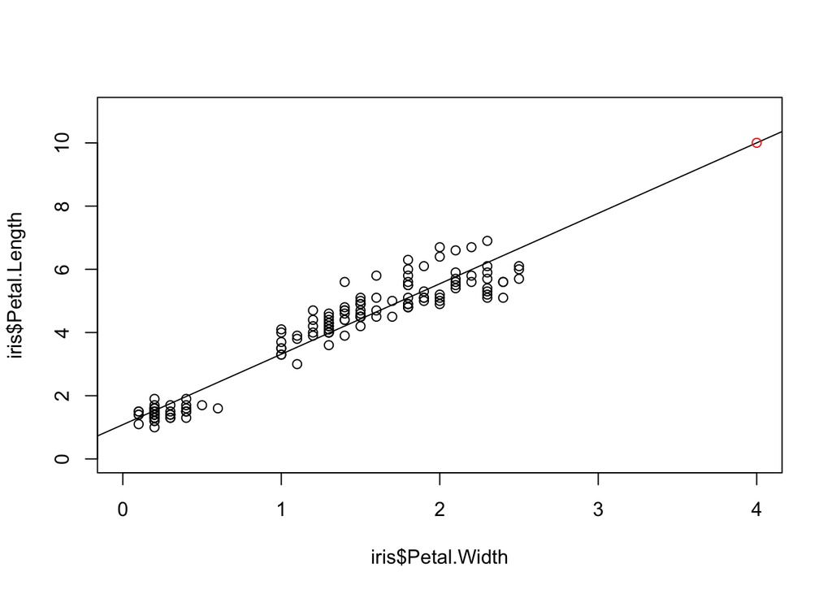

```r
#Question 27
#Code
plot(iris$Petal.Width,iris$Petal.Length,
  abline(m1),
  xlim=c(0,4),
  ylim=c(0,11))
points(4,predicted, col="red")
```

**Q28**: Try the same thing but without `xlim` and `ylim` in the plot function. What happens?

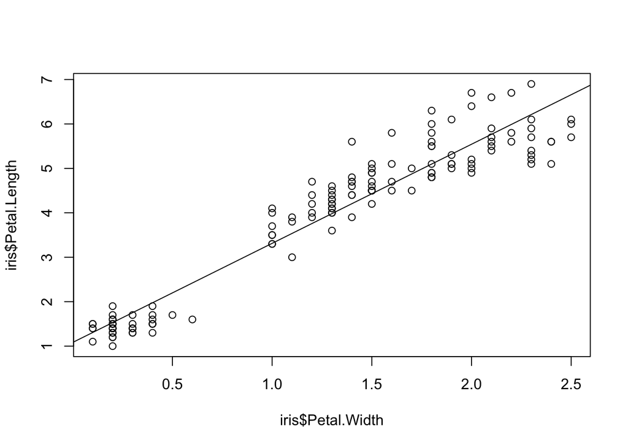

```r
#Question 28
#Code
plot(iris$Petal.Width,iris$Petal.Length,
  abline(m1))
points(4,predicted, col="red")
```

```r
#Answer
#The point falls outside of the plotting area and therefore does not show up
```

# 6 Dimensionality reduction

Most of the statistics we have dealt with so far are suitable for both small and large datasets. However, when dealing with larger datasets, there are specific methods used to cluster and summarise the data. Typically we call data *big data* when a dataset has many samples and many observations per sample, like for example when we have information on the expression of thousands of genes per individual. Data with information on many variables is sometimes called high dimensional data. In the last part of today’s tutorial we will return to the gene expression dataset to calculate principal components and run some clustering.

## 6.1 Normalization and data visualization

In order to perform certain downstream analyses, such as principal component analysis (PCA), or clustering, we need to properly normalise the expression counts first.

Let’s start by saving some information regarding the gene expression dataset as `colData`:

```r
# Use the information in the column names to generate a data.frame comprising the sample information.
library(stringr)

names = colnames(exp)
colData <- data.frame(row.names = names,
                      type = str_split_fixed(names, "_", 3)[,1],
                      sample = str_split_fixed(names, "_", 3)[,2],
                      stimulation = str_split_fixed(names, "_", 3)[,3])

# Add library size, which is the total ammount of gene reads per sample
colData$libSize <- colSums(exp)

# Make sure that the colnames of your count table are matching with the row names of your colData
all(rownames(colData) %in% colnames(exp))
```

```
## [1] TRUE
```

**Q29**: What information can you find in the newly made column `libSize`? What’s the minimum and maximum value of `libSize`?

```r
#Question 29
#Code
max(colData$libSize)
```

```
## [1] 8255943
```

```r
min(colData$libSize)
```

```
## [1] 5840615
```

```r
#Answer
#This column shows the total number of reads per sample
#The minimum is 5840615, the maximum is 8255943
```

Install and load the following packages: **DESeq2**, **ggplot2**, **ggsci**, **ggrepel**, **RColorBrewer**, **pheatmap**

```r
if (!requireNamespace("BiocManager", quietly = TRUE))
    install.packages("BiocManager")

BiocManager::install("GenomeInfoDbData")

library(GenomeInfoDbData)

if (!requireNamespace("BiocManager", quietly = TRUE))
    install.packages("BiocManager")

BiocManager::install("DESeq2")

#or try
source("https://bioconductor.org/biocLite.R")
biocLite("DESeq2")
```

There are multiple ways in which we can approximate our counts to a normal-like distribution. The **DESeq2** package provides two built-in functions to normalise your data:

- Regularized logarithm, or rlog
- Variance stabilizing transformations, or VST

```r
dds_stim <- DESeqDataSetFromMatrix(countData = exp,
                              colData = colData,
                              design = ~ stimulation+sample)

vst_stim <- assay(vst(dds_stim, blind=FALSE))
```

## 6.2 Principal component analysis (PCA)

PCA will help assess which samples are more closely related to each other, and how much variation is found between samples.

Follow the next steps to include the observations at t=0 unstimulated, t=180 unstimulated and t=180 stimulated in 1 PCA plot.

**Q30**:

- Calculate PCs using `prcomp(t(vst_stim))`
- Save these PCs as `pcData`
- The importance of each component is displayed in `summary(pcData)`
- What proportion of Variance does the first PC explain?
- Save the importance of components as `pcVar`

```r
#Question 30
#Code
# To calculate the components by sample we need to transpose our matrix of normalized gene expression
pcData <- prcomp(t(vst_stim))
pcVar <- summary(pcData)
# By getting the summary() of a prcomp object (in this case pcData) we can also obtain the total ammount of variance explained by each of the components.

#Answer
#The variance of PC1 is 0.5726 (or 57%)
```

**Q31**:

- Extract the importance of PC1 using `pcVar$importance[2,1]`
- Save this number as `varPC1`
- Do the same for PC2
- Make a data frame for plotting: `pcPlotData <- data.frame(pcData$x[,1:2], colData[rownames(pcData$x),])`
- Examine `pcPlotData` using `head()`
- What information do you have in this data frame?

```r
#Question 31
#Code
# We can then extract the variance explained by components 1 and 2.
varPC1 <- pcVar$importance[2,1]
varPC2 <- pcVar$importance[2,2]
pcPlotData <- data.frame(pcData$x[,1:2], colData[rownames(pcData$x),])
#head(pcPlotData)

#Answer
#Per sample, there is information on their loadings of PC1 and PC2, the sample, stimulation and library size
```

Make the plot using this code:

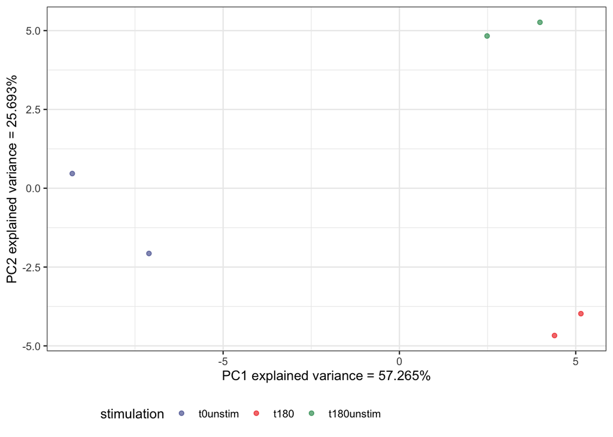

```r
pcaPlot_stim <- ggplot(pcPlotData, aes(x=PC1 , y=PC2 , color=stimulation))+
                  geom_jitter(alpha=0.6)+
                  xlab(paste0("PC1 explained variance = ", varPC1*100, "%"))+
                  ylab(paste0("PC2 explained variance = ", varPC2*100, "%"))+
                  scale_color_aaas()+
                  theme_bw()+
                  theme(legend.position = "bottom")+
                  guides(col = guide_legend(ncol = 8))

# display the pca plot in "Plots"
pcaPlot_stim
```

Use the following code to save your plot:

```r
# to save your file to pdf format in your working directory do
pdf("DIRECTORY WHERE YOU SAVED THE DATA/PCA_GM12878.pdf", height = 7.5, width=7.5)
pcaPlot_stim
dev.off()
```

**Q32 (bonus)**: Make the PC plot, this time color the dots by the `sample` instead of the `stimulation`. Can you also observe a pattern here?

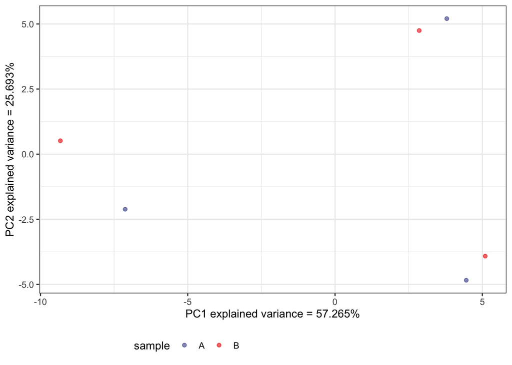

```r
#Question 32
#Code
pcaPlot_sample <- ggplot(pcPlotData, aes(x=PC1 , y=PC2 , color=sample))+
                  geom_jitter(alpha=0.6)+
                  xlab(paste0("PC1 explained variance = ", varPC1*100, "%"))+
                  ylab(paste0("PC2 explained variance = ", varPC2*100, "%"))+
                  scale_color_aaas()+
                  theme_bw()+
                  theme(legend.position = "bottom")+
                  guides(col = guide_legend(ncol = 8))

# display the pca plot in "Plots"
pcaPlot_sample
```

```r
#Answer
#No, the samples are nicely clustering together and there does not seem to be an effect of sample
```

# 7 Unsupervised clustering

Alternatively, it’s possible to assess the similarity between samples using an unsupervised clustering approach using the whole trancriptome to generate a distance matrix.

**Q33**: Follow the next steps to make clusters and show a heatmap:

```r
# Again we need to transpose our matrix to calculate the distance between each of the samples.
sampleDists <- dist(t(vst_stim))
sampleDistMatrix <- as.matrix(sampleDists)

# By using brewer.pal() we can generate a palette of colors, for more colors check (http://colorbrewer2.org/)
colors <- colorRampPalette(brewer.pal(9, "GnBu"))(255)

pheatmap(sampleDistMatrix, main = "Stimulation",
         show_colnames = FALSE,
         annotation = colData[,c("stimulation","sample")],
         clustering_distance_rows=sampleDists,
         clustering_distance_cols=sampleDists,
         col=colors)
```

What is the biggest difference in these experiments: the sample (A/B), the time (t=0 / t=180) or the stimulation (stimulated / unstimulated)? *Hint*: Look at the dendogram on the left of the graph.

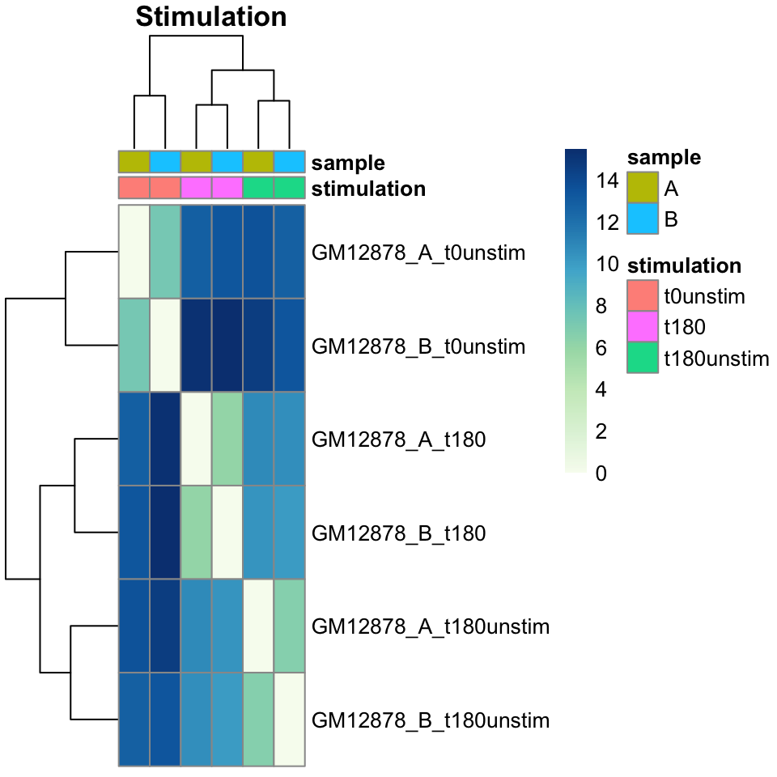

```r
#Question 33
#Code
# Again we need to transpose our matrix to calculate the distance between each of the samples.
sampleDists <- dist(t(vst_stim))
sampleDistMatrix <- as.matrix(sampleDists)

# By using brewer.pal() we can generate a palette of colors, for more colors check (http://colorbrewer2.org/)
colors <- colorRampPalette(brewer.pal(9, "GnBu"))(255)

pheatmap(sampleDistMatrix, main = "Stimulation",
         show_colnames = FALSE,
         annotation = colData[,c("stimulation","sample")],
         clustering_distance_rows=sampleDists,
         clustering_distance_cols=sampleDists,
         col=colors)
```

```r
#Answer
#The heatmap shows a similar results to the PCA: the biggest difference is the time point, closely followed by the stimulation. The sample has (almost) no influence.
```